# Regression (The Math Sorcerer)

Luis Cárceles

2024-04-09

See The [YouTube play list](https://www.youtube.com/playlist?list=PLO1y6V1SXjjNzyx0pl5M0O_rVMlHN0ZZ0) by the Math Sorcerer

## Introduction

Linear model: The relation between the two variables, $Y$ and $X$, is described by a linear equation.

$$Y_{i}=\beta_{0}+\beta_{1}X_{i}+E_{i}$$

$\beta_{0}$ is called *Intercept* and $\beta_{1}$ is called the *slope*. $E_{i}$ is a random variable with distribution $N(0,\sigma^2)$

The least square estimators of the coefficients $\beta_{0}$ and $\beta_{1}$ are:

$$B_{1}=\hat{\beta_{1}}=\frac{n\sum_{i=1}^nX_{i}Y_{i}-(\sum_{i=1}^nX_{i})(\sum_{i=1}^nY_{i})}{n\sum_{i=1}^nX_{i}^2-(\sum_{i=1}^nX_{i})^2}$$

$$B_{0}=\hat{\beta_{0}}=\bar{Y}-B_{1}\bar{X}$$

### Hypothesis Test about $\beta_{1}$ and $\beta_{0}$

First, we build the hypothesis test for $\beta_{1}$

To build our hypothesis test we consider three different cases

I: Left tailed test:

- $H_{0}$: $\beta_{1}=0$
- $H_{1}$: $\beta_{1}<0$

II: Right tailed test:

- $H_{0}$: $\beta_{1}=0$
- $H_{1}$: $\beta_{1}>0$

III: Two tailed test:

- $H_{0}$: $\beta_{1}=0$
- $H_{1}$: $\beta_{1}\ne0$

The statistic to be used is:

$$T_{n-2}=\frac{B_{1}}{S/\sqrt{S_{xx}}}$$

Where $B_{1}$ is the estimation of the slope, $S_{xx}=\sum_{i=1}^n(X_{i}-\bar{X})^2$ and $T_{n-2}$ is a random variable that has a Student T distribution with $n-2$ degrees of freedom. $S$ is an unbiased estimator of $\sigma^2$, which is the population standard deviation of $Y$ and can be computed as:

$$S^2=\frac{SSE}{n-2}=\frac{\sum_{i=1}^n(Y_{i-B_{0}-B_{1}X_{i}})^2}{n-2}$$

$SSE$ is denoted as the sum of square errors.

Now we are going to build the hypothesis test for the intercept $\beta_{0}$. Like $\beta_{1}$ we have:

I: Left tailed test:

- $H_{0}$: $\beta_{0}=0$
- $H_{1}$: $\beta_{0}<0$

II: Right tailed test:

- $H_{0}$: $\beta_{0}=0$
- $H_{1}$: $\beta_{0}>0$

III: Two tailed test:

- $H_{0}$: $\beta_{0}=0$
- $H_{1}$: $\beta_{0}\ne0$

The statistic to be used is:

$$T_{n-2}=\frac{B_{0}}{(\frac{S\sqrt{\sum_{i=1}^nX_{i}^2}}{\sqrt{nS_{xx}}})}$$

Where $T_{n-2}$ is a random variable that has a Student T distribution with $n-2$ degrees of freedom.

### Confidence intervals for $\beta_{1}$ and $\beta_{0}$

The bounds of the $100(1-\alpha)$ % confidence interval for $B_{1}$ can be computed as:

$$B_{1}\pm
t_{\alpha/2}S/\sqrt{S_{xx}}$$

And the bounds of the $100(1-\alpha)$ % confidence interval for $B_{0}$:

$$B_{0}\pm
t_{\alpha/2}\frac{S\sqrt{\sum_{i=1}^n}X_{i}^2}{\sqrt{nS_{xx}}}$$

In both cases the distribution of $t$ is Student T with $n-2$ degrees of freedom.

## Problems

### Problem 1

Chest size (inches): 44, 41, 41, 55, 51, 42

Weight (pounds): 213, 206, 176, 309, 300, 178

Solution:

Insert the data in a R data frame and then make an scatter plot of the data

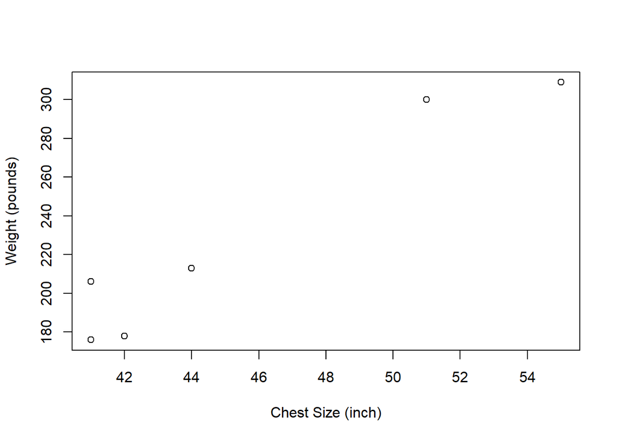

```r
# Create a data frame
Bears <- data.frame (
  ChestSize = c(44, 41, 41, 55, 51, 42),
  Weight = c(213, 206, 176, 309, 300, 178)
)

# Plot the data
plot(Bears$ChestSize, Bears$Weight, xlab='Chest Size (inch)', ylab='Weight (pounds)')
```

We can do a correlation test between the two variables:

```r
cor.test(Bears$ChestSize, Bears$Weight)
```

```
##
##  Pearson's product-moment correlation
##
## data:  Bears$ChestSize and Bears$Weight
## t = 7.1924, df = 4, p-value = 0.00198
## alternative hypothesis: true correlation is not equal to 0
## 95 percent confidence interval:
##  0.6963794 0.9961343
## sample estimates:
##       cor
## 0.9634452
```

The data seem highly correlated (0.96). The hypothesis test says that, at 5% of significance level, the hypothesis that correlation is 0 must be rejected and there is sufficient evidence to support a positive correlation between the two variables.

Lets calculate the regression line

```r
regr<-lm(formula=Weight~ChestSize, data=Bears)
summary(regr)
```

```
##
## Call:
## lm(formula = Weight ~ ChestSize, data = Bears)
##
## Residuals:
##       1       2       3       4       5       6
##  -1.234  20.745  -9.255 -11.490  18.148 -16.914
##
## Coefficients:
##             Estimate Std. Error t value Pr(>|t|)
## (Intercept) -210.793     61.760  -3.413  0.02695 *
## ChestSize      9.660      1.343   7.192  0.00198 **
## ---
## Signif. codes:  0 '***' 0.001 '**' 0.01 '*' 0.05 '.' 0.1 ' ' 1
##
## Residual standard error: 17.78 on 4 degrees of freedom
## Multiple R-squared:  0.9282, Adjusted R-squared:  0.9103
## F-statistic: 51.73 on 1 and 4 DF,  p-value: 0.00198
```

And plot the data with the regression line

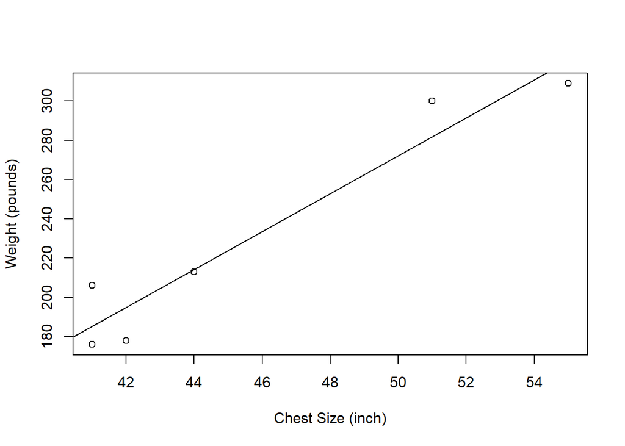

```r
plot(Bears$ChestSize, Bears$Weight,
     xlab='Chest Size (inch)',
     ylab='Weight (pounds)',
     abline(b = regr$coefficients[2], a = regr$coefficients[1]))
```

It is always a good idea to have a look to the residuals

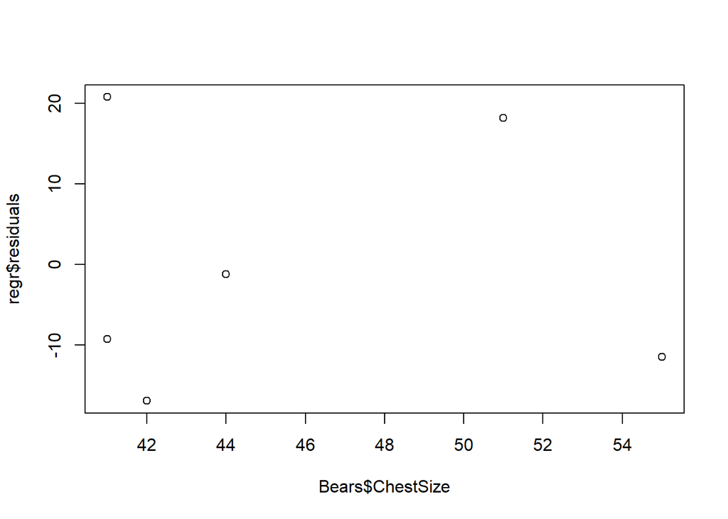

```r
plot(Bears$ChestSize, regr$residuals)
```

Which seem to be randomly generated. Finally were are asked to predict the weight of a bear with a chest size of 39 inches:

The correlation test and the linear model shows that we can use the linear equation to make that prediction

```r
Weight_pred<-regr$coefficients["(Intercept)"] + regr$coefficients["ChestSize"] * 39
sprintf("The predicted weigth value is: %f", Weight_pred)
```

```
## [1] "The predicted weigth value is: 165.935361"
```

### Problem 2

Find the regression equation, letting overhead width be the predictor x variable. Find the best predicted weight of a seal if the overhead width measured from a photograph is 1.6 cm. Can the prediction be correct?. What is wrong with predicting the wight in this case?. Use a significance level of 0.005.

Overhead Width (cm): 7.4, 7.7, 8.6, 8.4, 7.2, 9.3

Weight (kg): 133, 176, 207, 172, 145, 237

Solution

Insert the data in a R data frame and then make an scatter plot of the data

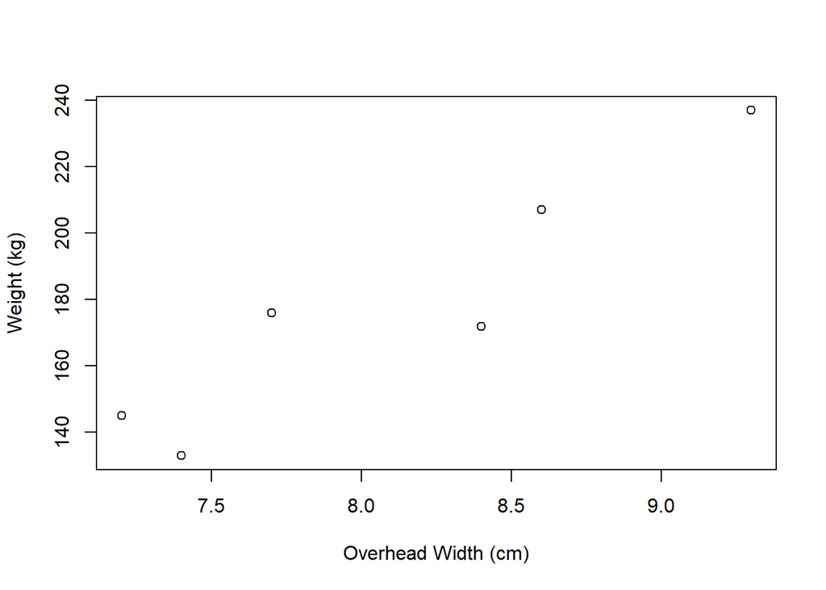

```r
# Create a data frame
Weigths <- data.frame (
  width = c(7.4, 7.7, 8.6, 8.4, 7.2, 9.3),
  weigth = c(133, 176, 207, 172, 145, 237)
)

# Plot the data
plot(Weigths$width, Weigths$weigth, xlab='Overhead Width (cm)', ylab='Weight (kg)')
```

We can do a correlation test between the two variables:

```r
cor.test(Weigths$width, Weigths$weigth)
```

```
##
##  Pearson's product-moment correlation
##
## data:  Weigths$width and Weigths$weigth
## t = 5.2693, df = 4, p-value = 0.006215
## alternative hypothesis: true correlation is not equal to 0
## 95 percent confidence interval:
##  0.5113302 0.9930273
## sample estimates:
##       cor
## 0.9349216
```

Lets calculate the regression line

```r
fit<-lm(formula=weigth~width, data=Weigths)
summary(fit)
```

```
##
## Call:
## lm(formula = weigth ~ width, data = Weigths)
##
## Residuals:
##       1       2       3       4       5       6
## -13.898  15.630   6.213 -19.806   7.083   4.778
##
## Coefficients:
##             Estimate Std. Error t value Pr(>|t|)
## (Intercept) -185.417     69.315  -2.675  0.05552 .
## width         44.907      8.522   5.269  0.00621 **
## ---
## Signif. codes:  0 '***' 0.001 '**' 0.01 '*' 0.05 '.' 0.1 ' ' 1
##
## Residual standard error: 15.34 on 4 degrees of freedom
## Multiple R-squared:  0.8741, Adjusted R-squared:  0.8426
## F-statistic: 27.77 on 1 and 4 DF,  p-value: 0.006215
```

And plot the data with the regression line

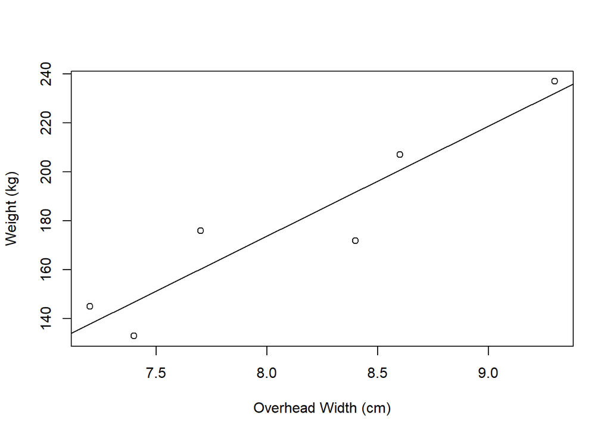

```r
plot(Weigths$width, Weigths$weigth,
     xlab='Overhead Width (cm)',
     ylab='Weight (kg)',
     abline(b = fit$coefficients["width"], a = fit$coefficients["(Intercept)"]))
```

```r
fit_pred<-fit$coefficients["(Intercept)"] + fit$coefficients["width"] * 1.6
sprintf("The predicted weigth value is: %f", fit_pred)
```

```
## [1] "The predicted weigth value is: -113.564815"
```

The prediction cannot be correct because a negative weight does not make sense. The width in this case is beyond the scope of the available sample data.